# MTH 448 - Project 1

Nicholas Colan, UB: 50142568

# Introduction

The K-NN algorithm is a supervised machine learning algorithm that is used for both classification and regression of data. It is an algorithm that does not take any assumptions about the distribution of the data that it will classify. This is also called a non-parametric method. K-NN works by taking a data point and considering the 'K' nearest neighbors. It then uses a voting system to determine which class the data point belongs to. The data point is assigned to the class most common among its 'K' nearest neighbors.

In this report we will design an implementation of the K-NN algorithm and apply it to the **MNIST** database. The MNIST database is a large database of handwritten digits that is used to train and test models of machine learning and computer vision. It is composed of 60,000 training images and 10,000 testing images. Each image is of a size of 28x28 pixels, and each image is grayscale. Each image is labeled with the corresponding digit it depicts, ranging from 0 to 9.

This report will explore how making slight modifications to the K-NN algorithm can produce differing levels of accuracy in data classification when trying to classify MNIST images. We will look at how different values of k and different data set sizes will affect the classification accuracy of the k-nn algorithm. We will also look at how well the images in the MNIST dataset are labeled, and whether or not some images are labeled completely incorrect.

We will first start off by importing all of the necessary libraries that we will need for this report, and configure the Jupyter notebook to sharpen the resolution of the graphs present:

```python
from pathlib import Path
import requests
import numpy as np
import gzip
import matplotlib.pyplot as plt
from sklearn.datasets import make_blobs
from matplotlib.colors import ListedColormap, Normalize
from sklearn.neighbors import KNeighborsClassifier
from scipy import stats
from time import time

%config InlineBackend.figure_format = 'retina'
```

# Part 1 - Create a function `knn_classifier()` which implements the K-NN classification algorithm.

Before we can implement our K-NN classification algorithm, we will first need to pull all of the data from the MNIST database and store it in variables `images` and `labels`. Each index of `images` and `labels` corresponds to the same handwritten digit. We will make use of pythons `requests` library to download the necessary files off of the MNIST database, and store them locally in files.

```python
def get_MNIST():
    mnist_url = "http://yann.lecun.com/exdb/mnist/"
    img_file = "ncolan_train-images-idx3-ubyte.gz"
    labels_file = "ncolan_train-labels-idx1-ubyte.gz"

    for fname in [img_file, labels_file]:
        if Path(fname).is_file() :
            print(f"Found: {fname}")
            continue
        print(f"Downloading: {fname}")
        r = requests.get(mnist_url + fname)
        with open(fname, 'wb') as foo:
            foo.write(r.content)

    with gzip.open(labels_file, 'rb') as foo:
        e = foo.read()

    with gzip.open(img_file, 'rb') as foo:
        f = foo.read()

    labels = np.array([b for b in e[8:]])
    images = np.array([b for b in f[16:]]).reshape(-1, 28*28)

    return labels, images
```

```python
labels, images = get_MNIST()
```

```
Found: ncolan_train-images-idx3-ubyte.gz
Found: ncolan_train-labels-idx1-ubyte.gz
```

Now that we have our data loaded into 2 variables, `images` and `labels`, we can now create functions necessary to compute the k-nearest neighbors of each point. We will make use of Euclidean distance in order to compute the distance between neighbors. Eucledian distance (or norm-2) is a measure of similarity between two points in a space, calculated as the straight-line distance between them. We can use it to calculate how far away points in the MNIST dataset are from eachother to determine a point's closest neighbors.

The function `dist(X,w)` calculates the Eucledian distance between all of the points of 2 different vectors. The function `n_smallest(a,n)` returns the indices of the `n` smallest values in a vector. In this case we will use `n_smallest(a,n)` to return the shortest `n` distances calculated in `dist(X,w)` in order to find the `k`-closest neighbors of a point in space.

The function `find_kNN(k,data,point)` takes three inputs:

- `k` - the number of nearest neighbors to return
- `data` - the set of all data points as a vector
- `point` - the index in 'data' of interest

This function combines these two functions and will return the `k` closest points in `data` to our point of interest, `point`.

```python
def find_kNN(k,data,point):
    def dist(X,w): return np.linalg.norm(X-w, axis=1)
    def n_smallest(a,n): return np.argsort(a)[:n]

    if k == -1:
        return np.array([n_smallest(dist(data[x],data),-1) for x in range(len(data))])
    else:
        return n_smallest(dist(data[point],data),k+1)
```

With the functionality necessary to calculate the k-nearest neighbors created, we can now package it all otgether into one function. The function `knn_classifier(training_data,training_labels,x,k)` takes four inputs:

- `training_data` - The MNIST image data
- `training_labels` - The MNIST labels data
- `x` - The point we are interested in
- `k` - The amount of neighbors to classify

This function returns a tuple of `(label,neighbors)` where:

- `label` - The predicted label of `x`
- `neighbors` - The `k` nearest neighbors of `x`

This function classifies `x` by using the most common occuring neighbor of point `x`. I have added functionality to calculate the distance of all the neighbors of the point by inputting `-1` for `k`.

```python
def knn_classifier(training_data,training_labels,x,k):

    def find_kNN(k,data,point):
        def dist(X,w): return np.linalg.norm(X-w, axis=1)
        def n_smallest(a,n): return np.argsort(a)[:n]
        if k == -1:
            return np.array([n_smallest(dist(data[x],data),-1) for x in range(len(data))])
        else:
            return n_smallest(dist(data[point],data),k+1)

    kNeighbors = find_kNN(k,training_data,x)[1:]
    label = stats.mode(training_labels[kNeighbors])[0][0]

    return (label, kNeighbors)
```

To illustrate that our k-NN classifier works correctly, we will create a function `visualize_6_digits(x1,x2,x3,x4,x5,x6)` that takes 6 different images from the MNIST database and displays them:

```python
def visualize_6_digits(x1,x2,x3,x4,x5,x6):
    fig = plt.figure()
    plt.subplot(3,2,1)
    plt.imshow(x1.reshape(28,28),cmap='Greys')

    plt.subplot(3,2,2)
    plt.imshow(x2.reshape(28,28),cmap='Greys')

    plt.subplot(3,2,3)
    plt.imshow(x3.reshape(28,28),cmap='Greys')

    plt.subplot(3,2,4)
    plt.imshow(x4.reshape(28,28),cmap='Greys')

    plt.subplot(3,2,5)
    plt.imshow(x5.reshape(28,28),cmap='Greys')

    plt.subplot(3,2,6)
    plt.imshow(x6.reshape(28,28),cmap='Greys')
```

We will now run one instance of our `knn_classifier()` algorithm on the second point in the dataset. We can see that the correct label is `0`, and that the image also clearly is a `0`.

```
0
```

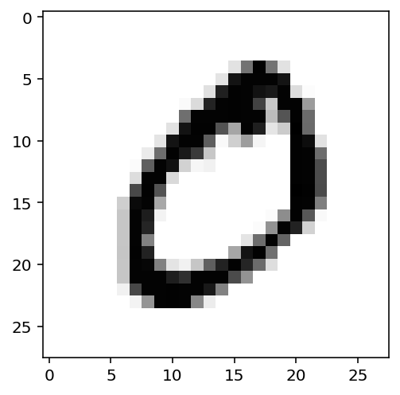

```python
point = 1
print(labels[point])
plt.imshow(images[point].reshape(28,28),cmap='Greys')
```

Now lets use our `knn_classifier()` function to classify the point, and the images of that points 6-closest neighbors calculated by our function:

```
(0, array([  639, 51121, 59187, 31059,  2581, 32388]))
```

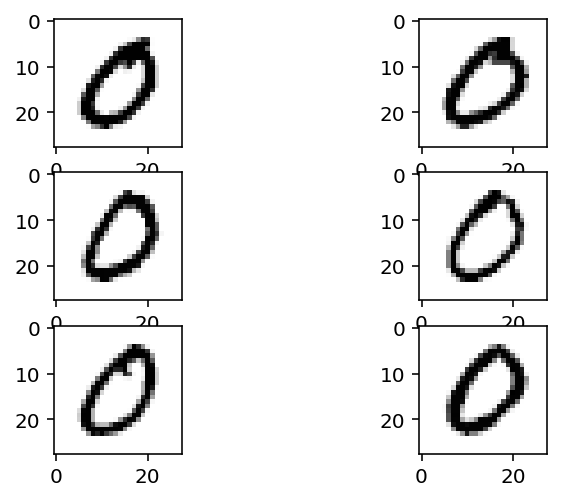

```python
x = knn_classifier(images,labels,point,6)
print(x)
visualize_6_digits(images[x[1][0]],images[x[1][1]],images[x[1][2]],images[x[1][3]],images[x[1][4]],images[x[1][5]])
```

We can see that our `knn_classifier()` function works as intended, correctly classifying an image and returning neighbors that have the same label as the input point.

# Part 2:

# Which value of k produces the most accurate prediction?

The k-nearest neighbor classification uses the value of k to determine how many neighbors in the training dataset to use for making predictions. A higher k value means that more neighbors are used for making a prediction, which should result in a prediction that is less likely to be affected by noise in the data. A lower k value means that fewer neighbors are used for making a prediction, which can lead to a very accurate classification, but one that is more suseptible to noise or errors in the data. Therefore, the value of k needs to be carefully chosen to ensure that the best prediction accuracy is achieved. We will look at different values of k and how they affect classification accuracy.

To go about researching which value of k is most accurate, I have written a function `differentK_accuracy(images,labels)`. This function takes 2 inputs:

- `images` - The MNIST image data
- `labels` - The MNIST label data

This will return a list contaning all values of k between 3 and 100 and how accurate the prediction is with that k-value. We are using the `sklearn` library's implementation of the k-NN algorithm, as it is a very efficient and fast method.

```python
def differentK_accuracy(images,labels):

    kVals = np.arange(3,100,1)
    accuracies = []

    for k in kVals:
        numCorrect = 0
        knn = KNeighborsClassifier(k)
        knn.fit(images,labels)
        a = knn.predict(images)
        b = (a==labels)
        acc = (b.sum()/len(b)) # np.array().sum() will return the amount of True values in the array
        accuracies.append((k,acc))

    return accuracies
```

Now running this function on the entire MNIST database takes a very long time (about 5.5 hours), so in order for quick access to the data that is generated by this function, I have included the results in a file named `ncolan_sklearnKNN_differentKValues.txt`. The code below generates, saves, and then loads the data from this file into `differentK_results`.

```python
#a = differentK_accuracy(images,labels)
```

```python
# Write these results to this file
filename1 = 'ncolan_sklearnKNN_differentKValues.txt'
```

```python
#with open(filename1,'w') as f:
    #for i in a:
        #f.write('{:} - {:}\n'.format(i[0],i[1]))
```

```python
# Pull the contents of the file
with open (filename1,'r') as f:
    differentK_results = np.array([value.strip().split(' - ') for value in f],dtype=float)
```

Looking at the data in the file, we can see that the most accurate classification came when we used `k = 3` for our k-NN classification. `K = 3` produced the best result for k-NN because it was able to accurately classify data points while also avoiding the over-fitting problems that can occur with a higher k-value. Below we can see how the accuracy of classification changes with differing values of `k`.

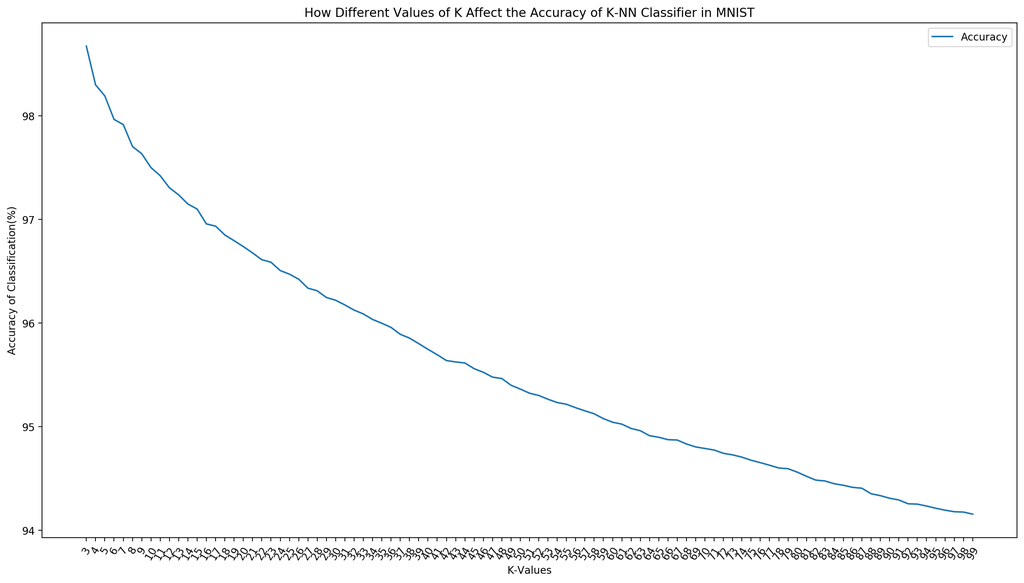

```python
x_values = np.array([i[0] for i in differentK_results],dtype=int)
y_values = np.array([i[1] for i in differentK_results])*100
x_ticks = np.arange(len(x_values))

plt.figure(figsize=(14,8),dpi=100)
plt.plot(x_ticks,y_values,label='Accuracy')
plt.xticks(x_ticks,x_values,rotation=60)
plt.xlabel('K-Values')
plt.ylabel('Accuracy of Classification(%)')
plt.title('How Different Values of K Affect the Accuracy of K-NN Classifier in MNIST')
plt.legend()
plt.tight_layout()
```

# How does the size of the training set affect the classification accuracy?

The size of the training set has a direct impact on the accuracy of KNN classification. The larger the training set, the higher the accuracy of classification should be, as a larger dataset should provide more information for the algorithm to learn from. Conversely, a smaller training set should result in less accurate results. We will use a k value of `3`, as it was found from the previous test that `k = 3` provided the most accurate classification.

For this we will define a new function, `differentTrainingSetSize_accuracy(images,labels,k)` which takes three inputs:

- `images` - The MNIST image data
- `labels` - The MNIST label data
- `k` - The amount of k-neighbors to use

This function will return a list of `[(size,accuracy)]`, which represents the relation of the size of the dataset to the accuracy of the k-nn classifier. This function also uses a `Boolean` mask and `numpy.ndarray.sum()` to find the amount of `True` values, and compares the amount of `True` values to the amount of neighbors to calculate the accuracy.

```python
def differentTrainingSetSize_accuracy(images,labels,k):
    setSize = np.arange(500,len(images),1000) # We will increase the training set by 1000 each time (1.6%)
    accuracies = []

    for size in setSize:
        numCorrect = 0
        knn = KNeighborsClassifier(k)
        knn.fit(images[:size],labels[:size])
        a = knn.predict(images[:size])
        b = (a==labels[:size])
        acc = (b.sum()/len(b)) # np.array().sum() will return the amount of True values in the array
        accuracies.append((size,acc))

    return accuracies
```

Again I have pre-run this method on the entire dataset and have saved the results in a file named `ncolan_sklearnKNN_differentSetSizeValues_3KNeighbors.txt` as it will take a long time to generate these reults when applying to the entire MNIST dataset.

```python
filename2 = 'ncolan_sklearnKNN_differentSetSizeValues_3KNeighbors.txt'
```

```python
#b = differentTrainingSetSize_accuracy(images,labels,3)

#with open(filename2,'w') as f:
    #for i in b:
        #f.write('{:} - {:}\n'.format(i[0],i[1]))
```

```python
with open (filename2,'r') as f:
    differentSetSize3_results = np.array([value.strip().split(' - ') for value in f],dtype=float)
```

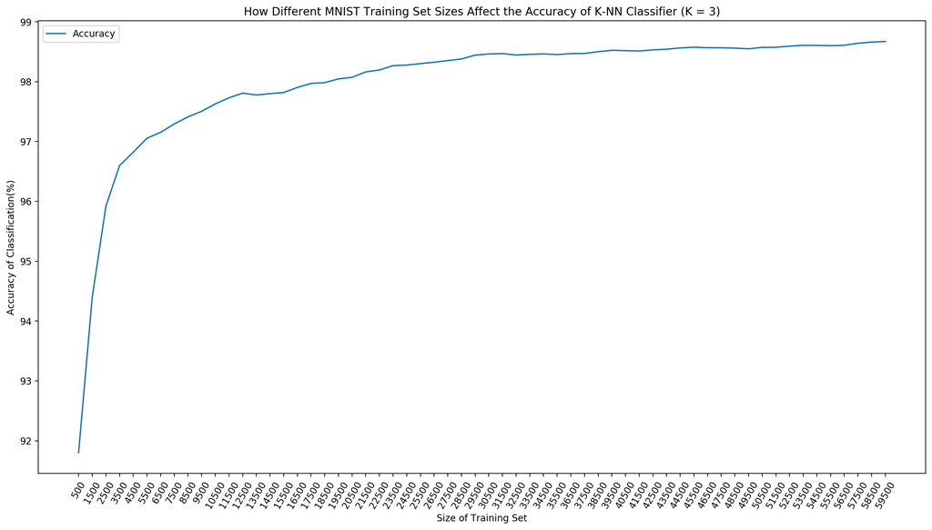

```python
x_values2 = np.array([i[0] for i in differentSetSize3_results],dtype=int)
y_values2 = np.array([i[1] for i in differentSetSize3_results])*100
x_ticks2 = np.arange(len(x_values2))

plt.figure(figsize=(14,8),dpi=100)
plt.plot(x_ticks2,y_values2,label='Accuracy')
plt.xticks(x_ticks2,x_values2,rotation=60)
plt.xlabel('Size of Training Set')
plt.ylabel('Accuracy of Classification(%)')
plt.title('How Different MNIST Training Set Sizes Affect the Accuracy of K-NN Classifier (K = 3)')
plt.legend()
plt.tight_layout()
```

We can see that increasing the size of the dataset has a direct impact on classification accuracy.

We will now run these same tests but will a slightly large k-value of `5` to see how that affects classification accuracy with increasing dataset sizes. Again, I have already run and saved these results in a file named `ncolan_sklearnKNN_differentSetSizeValues_5KNeighbors.txt`.

```python
filename3 = 'ncolan_sklearnKNN_differentSetSizeValues_5KNeighbors.txt'
```

```python
#c = differentTrainingSetSize_accuracy(images,labels,5)
#c
```

```python
#with open(filename3,'w') as f:
    #for i in c:
        #f.write('{:} - {:}\n'.format(i[0],i[1]))
```

```python
with open (filename3,'r') as f:
    differentSetSize5_results = np.array([value.strip().split(' - ') for value in f],dtype=float)
```

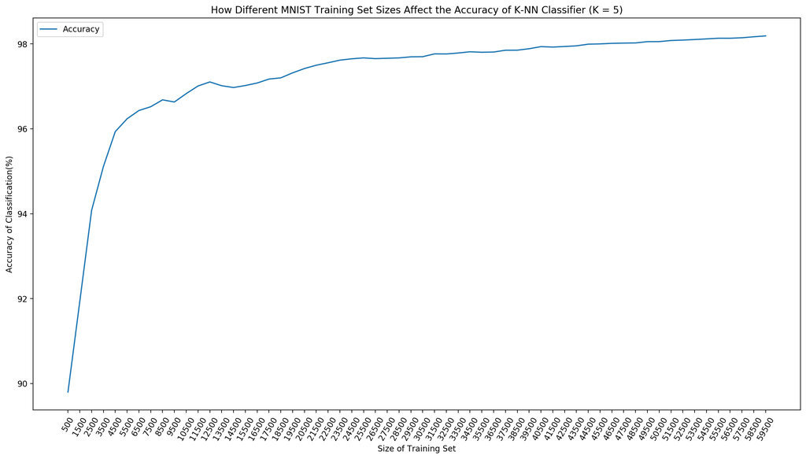

```python
x_values3 = np.array([i[0] for i in differentSetSize5_results],dtype=int)
y_values3 = np.array([i[1] for i in differentSetSize5_results])*100
x_ticks3 = np.arange(len(x_values3))

plt.figure(figsize=(14,8),dpi=100)
plt.plot(x_ticks3,y_values3,label='Accuracy')
plt.xticks(x_ticks3,x_values3,rotation=60)
plt.xlabel('Size of Training Set')
plt.ylabel('Accuracy of Classification(%)')
plt.title('How Different MNIST Training Set Sizes Affect the Accuracy of K-NN Classifier (K = 5)')
plt.legend()
plt.tight_layout()
```

As we can see for either value of `k`, the larger the dataset is the more accurate our classification will become. We can see that `k = 3` was more accurate. The larger dataset did provide more information for the algorithm to learn from. The smaller training set did result in less accurate predictions, but it still produced almost a `90%` accuracy with an extremely small dataset of only `500` datapoints. This highlights the usefulness of the k-NN algorithm as it can be used with relatively good accuracy with any different dataset size.

# What Fraction Of Images Are Classified With Perfect Certainty?

We can see from above that `k = 3` produced the most accurate classification in our data set. However, it is important to realize that when only looking at the nearest 3 neighbors, that errors in the data can have a large effect on the outcome of classification. For that reason, we will use a k value of `5` to see how many images get classified perfectly (the images are classified correctly, and all of their k-nearest neighbors had the same label.)

We will create a function `perfect_accuracy(images,labels,k)`, which takes three inputs:

- `images` - The MNIST image data
- `labels` - The MNIST label data
- `k` - The amount of k-neighbors to use

This function will return a list of the form `[(index,index label,nearest k-neighbors)]` which will show what exact indices of the images were labeled with perfect accuracy, their label, and their k-closest neighbors. This will also use a `Boolean` mask and `numpy.ndarray.sum()`.

```python
def perfect_accuracy(images,labels,k):

    perfect = []
    knn = KNeighborsClassifier(k)
    knn.fit(images,labels)
    a = knn.kneighbors(n_neighbors=k)
    b = a[1]
    num = 0
    for i in b:
        c = labels[i] == labels[num]
        if c.sum() == c.size:
            perfect.append((num,labels[num],i))
        num += 1

    return perfect
```

Once again, I have already run and saved these results in a file named `ncolan_pointsClassifiedWithPerfectAccuracy.txt` for quick access due to the long runtime of calculating these results.

```python
#d = perfect_accuracy(images,labels,5)
#d
```

```python
filename4 = 'ncolan_pointsClassifiedWithPerfectAccuracy.txt'
#with open(filename4,'w') as f:
    #for i in d:
        #f.write('{:}\n'.format(i))
```

```python
with open (filename4,'r') as f:
    perfectAccuracy_results = [value.split('\n') for value in f]
```

```python
len(perfectAccuracy_results)/len(images) * 100
```

```
90.17333333333333
```

We can see that about `90.1%` of all the images in the dataset were classified with perfect accuracy. Some points in the MNIST dataset may not be labeled correctly due to human error, or because the data was collected in a noisy environment.

# How Many Images Were Classified With 0% Certainty? i.e. No neighbors had the correct label

We will now look at points in the dataset where all of the points nearest k-neighbors were labeled incorrectly. To do this we will create a function `zero_accuracy(images,labels,k)` whose inputs are:

- `images` - The MNIST image data
- `labels` - The MNIST label data
- `k` - The amount of k-neighbors to use

This function will return a list of `[(index,index label,nearest k-neighbors)]` which are all points whose neighbors have incorrect labels. This will again use a `Boolean` mask and `numpy.ndarray.sum()` and will record points where all of the neighbors had a different label.

```python
def zero_accuracy(images,labels,k):

    zero = []
    knn = KNeighborsClassifier(k)
    knn.fit(images,labels)
    a = knn.kneighbors(n_neighbors=k)
    b = a[1]
    num = 0
    for i in b:
        c = labels[i] == labels[num]
        if c.sum() == 0:
            zero.append((num,labels[num],i))
        num += 1

    return zero
```

This function also takes a little while to run, and I have pre-generated and stored the results in a file named `ncolan_pointsClassifiedWithZeroAccuracy.txt`.

```python
#e = zero_accuracy(images,labels,5)
#e
```

```python
filename5 = 'ncolan_pointsClassifiedWithZeroAccuracy.txt'
#with open(filename5,'w') as f:
    #for i in e:
        #f.write('{:}\n'.format(i))
```

```python
with open (filename5,'r') as f:
    zeroAccuracy_results = [value.split('\n') for value in f]
```

```python
len(zeroAccuracy_results)
```

```
424
```

```python
len(zeroAccuracy_results)/len(images)*100
```

```
0.7066666666666667
```

As we can see, a very few amount of the points `(424/60,000)` in the MNIST dataset have neighbors that all have the incorrect labels, only about `0.7%`. This could be due to the fact that the images were taken from different sources and contain different characteristics, making them difficult to classify correctly. Additionally, some of the points may have been misclassified due to random errors during the data collection and labeling process.

# Conclusion

In conclusion, the k-nn algorithm is a powerful and versatile tool for machine learning. It is relatively easy to implement and can be used in a variety of applications, such as classification and regression. Its ability to work with any dataset and its ability to classify unseen data make it a popular choice for many applications. The k-nn algorithm has been shown to be accurate and reliable in many cases, and its ability to modify its results based on different parameters makes it a powerful tool. With its robust performance and wide range of applications, the k-nn algorithm is a valuable tool for data analysis and machine learning.

In this report we looked at two different variables that could affect the accuracy of a k-NN classifier: the amount of k-neighbors to use and the size of the dataset that we use. Even though a larger k-value should provide an accurate classification while eliminating potential mis-classification due to noise or erros, it was actually found that a low value for k, `k = 3`, produced the most accurate classification of the images.

We also looked at varying dataset sizes and how that impacted the accuracy of classification of the imahes in the MNIST dataset. It was found that the larger the dataset, the more accurate the k-NN algorithm would be at classifying images. This is due to a larger dataset providing more information for the algorithm to 'learn' from.

We also explored the neighbors of images we looked at, and whether their labels perfectly matched our point of interest, or whether none of the neighbors had the same label. We found that just over `90%` of the images were classified perfectly when using a k value of 5, while only `0.7%` of the images had no neighbors witht he correct label when using a k value of 5.

The k-NN algorithm is capable of making accurate predictions for both classification and regression problems. It is easy to implement and works well with datasets of many different sizes and applications, and its performance can be easily tuned and improved by adjusting the value of k. Its main downside is that it can be computationally expensive when dealing with large datasets, as we saw when we tried to apply it to the entire MNIST dataset of 60,000 datapoints. Overall, the k-NN algorithm is a powerful tool for machine learning and data analysis.

# Code

```python
from pathlib import Path
import requests
import numpy as np
import gzip
import matplotlib.pyplot as plt
from sklearn.datasets import make_blobs
from matplotlib.colors import ListedColormap, Normalize
from sklearn.neighbors import KNeighborsClassifier
from scipy import stats
from time import time

%config InlineBackend.figure_format = 'retina'
```

## Part 1:

```python
def get_MNIST():
    mnist_url = "http://yann.lecun.com/exdb/mnist/"
    img_file = "ncolan_train-images-idx3-ubyte.gz"
    labels_file = "ncolan_train-labels-idx1-ubyte.gz"

    for fname in [img_file, labels_file]:
        if Path(fname).is_file() :
            print(f"Found: {fname}")
            continue
        print(f"Downloading: {fname}")
        r = requests.get(mnist_url + fname)
        with open(fname, 'wb') as foo:
            foo.write(r.content)

    with gzip.open(labels_file, 'rb') as foo:
        e = foo.read()

    with gzip.open(img_file, 'rb') as foo:
        f = foo.read()

    labels = np.array([b for b in e[8:]])
    images = np.array([b for b in f[16:]]).reshape(-1, 28*28)

    return labels, images

labels, images = get_MNIST()

def knn_classifier(training_data,training_labels,x,k):

    def find_kNN(k,data,point):
        def dist(X,w): return np.linalg.norm(X-w, axis=1)
        def n_smallest(a,n): return np.argsort(a)[:n]
        if k == -1:
            return np.array([n_smallest(dist(data[x],data),-1) for x in range(len(data))])
        else:
            return n_smallest(dist(data[point],data),k+1)

    kNeighbors = find_kNN(k,training_data,x)[1:]
    label = stats.mode(training_labels[kNeighbors])[0][0]

    return (label, kNeighbors)
```

## Part 2:

### Accuracy of Different k-Values:

```python
def differentTrainingSetSize_accuracy(images,labels,k):
    setSize = np.arange(500,len(images),1000) # We will increase the training set by 1000 each time (1.6%)
    accuracies = []

    for size in setSize:
        numCorrect = 0
        knn = KNeighborsClassifier(k)
        knn.fit(images[:size],labels[:size])
        a = knn.predict(images[:size])
        b = (a==labels[:size])
        acc = (b.sum()/len(b)) # np.array().sum() will return the amount of True values in the array
        accuracies.append((size,acc))

    return accuracies

a = differentK_accuracy(images,labels)

filename1 = 'ncolan_sklearnKNN_differentKValues.txt'
with open(filename1,'w') as f:
    for i in a:
        f.write('{:} - {:}\n'.format(i[0],i[1]))

with open (filename1,'r') as f:
    differentK_results = np.array([value.strip().split(' - ') for value in f],dtype=float)


x_values = np.array([i[0] for i in differentK_results],dtype=int)
y_values = np.array([i[1] for i in differentK_results])*100
x_ticks = np.arange(len(x_values))

plt.figure(figsize=(14,8),dpi=100)
plt.plot(x_ticks,y_values,label='Accuracy')
plt.xticks(x_ticks,x_values,rotation=60)
plt.xlabel('K-Values')
plt.ylabel('Accuracy of Classification(%)')
plt.title('How Different Values of K Affect the Accuracy of K-NN Classifier')
plt.legend()
plt.tight_layout()
```

### Different Training Set Sizes:

#### k = 3:

```python
def differentTrainingSetSize_accuracy(images,labels,k):
    setSize = np.arange(500,len(images),1000) # We will increase the training set by 1000 each time (1.6%)
    accuracies = []

    for size in setSize:
        numCorrect = 0
        knn = KNeighborsClassifier(k)
        knn.fit(images[:size],labels[:size])
        a = knn.predict(images[:size])
        b = (a==labels[:size])
        acc = (b.sum()/len(b)) # np.array().sum() will return the amount of True values in the array
        accuracies.append((size,acc))

    return accuracies


b = differentTrainingSetSize_accuracy(images,labels,3)

filename2 = 'ncolan_sklearnKNN_differentSetSizeValues_3KNeighbors.txt'
with open(filename2,'w') as f:
    for i in b:
        f.write('{:} - {:}\n'.format(i[0],i[1]))

with open (filename2,'r') as f:
    differentSetSize3_results = np.array([value.strip().split(' - ') for value in f],dtype=float)

x_values2 = np.array([i[0] for i in differentSetSize3_results],dtype=int)
y_values2 = np.array([i[1] for i in differentSetSize3_results])*100
x_ticks2 = np.arange(len(x_values2))

plt.figure(figsize=(14,8),dpi=100)
plt.plot(x_ticks2,y_values2,label='Accuracy')
plt.xticks(x_ticks2,x_values2,rotation=60)
plt.xlabel('Size of Training Set')
plt.ylabel('Accuracy of Classification(%)')
plt.title('How Different Training Set Sizes Affect the Accuracy of K-NN Classifier (K = 3)')
plt.legend()
plt.tight_layout()
```

#### k = 5:

```python
c = differentTrainingSetSize_accuracy(images,labels,5)

filename3 = 'ncolan_sklearnKNN_differentSetSizeValues_5KNeighbors.txt'
with open(filename3,'w') as f:
    for i in c:
        f.write('{:} - {:}\n'.format(i[0],i[1]))

with open (filename3,'r') as f:
    differentSetSize5_results = np.array([value.strip().split(' - ') for value in f],dtype=float)

x_values3 = np.array([i[0] for i in differentSetSize5_results],dtype=int)
y_values3 = np.array([i[1] for i in differentSetSize5_results])*100
x_ticks3 = np.arange(len(x_values3))

plt.figure(figsize=(14,8),dpi=100)
plt.plot(x_ticks3,y_values3,label='Accuracy')
plt.xticks(x_ticks3,x_values3,rotation=60)
plt.xlabel('Size of Training Set')
plt.ylabel('Accuracy of Classification(%)')
plt.title('How Different Training Set Sizes Affect the Accuracy of K-NN Classifier (K = 5)')
plt.legend()
plt.tight_layout()
```

### Labels Classified With Perfect Certainty:

```python
def perfect_accuracy(images,labels,k):

    perfect = []
    knn = KNeighborsClassifier(k)
    knn.fit(images,labels)
    a = knn.kneighbors(n_neighbors=k)
    b = a[1]
    num = 0
    for i in b:
        c = labels[i] == labels[num]
        if c.sum() == c.size:
            perfect.append((num,labels[num],i))
        num += 1

    return perfect

d = perfect_accuracy(images,labels,5)

filename4 = 'ncolan_pointsClassifiedWithPerfectAccuracy.txt'
with open(filename4,'w') as f:
    for i in d:
        f.write('{:}\n'.format(i))

with open (filename4,'r') as f:
    perfectAccuracy_results = [value.split('\n') for value in f]

len(perfectAccuracy_results)/len(images) * 100
```

### Labels Classified With 0% Certainty:

```python
def zero_accuracy(images,labels,k):

    zero = []
    knn = KNeighborsClassifier(k)
    knn.fit(images,labels)
    a = knn.kneighbors(n_neighbors=k)
    b = a[1]
    num = 0
    for i in b:
        c = labels[i] == labels[num]
        if c.sum() == 0:
            zero.append((num,labels[num],i))
        num += 1

    return zero

e = zero_accuracy(images,labels,5)


filename5 = 'ncolan_pointsClassifiedWithZeroAccuracy.txt'
with open(filename5,'w') as f:
    for i in e:
        f.write('{:}\n'.format(i))

with open (filename5,'r') as f:
    zeroAccuracy_results = [value.split('\n') for value in f]

len(zeroAccuracy_results)
len(zeroAccuracy_results)/len(images)*100
```

# References

- https://medium.com/analytics-vidhya/a-beginners-guide-to-knn-and-mnist-handwritten-digits-recognition-using-knn-from-scratch-df6fb982748a
- https://towardsdatascience.com/machine-learning-basics-with-the-k-nearest-neighbors-algorithm-6a6e71d01761
- https://www.ibm.com/topics/knn